Session 1: Generating Data & Asking Good Questions  
DSOM 5509: Applied Statistical Methods  
Brian S. Anderson, Ph.D.  
Associate Professor  
Department of Global Entrepreneurship & Innovation  
andersonbri@umkc.edu

[figure not shown]

© 2019 Brian S. Anderson

**Plan of the Day**

- Administrivia
- R and RStudio Review
- Data Science Workflow
- Generating Research Questions

**Administrivia**

- [Course website](https://dsom5509.github.io)
- [RStudio Cloud](https://rstudio.cloud/)

Class approach and why I don’t provide a deck in advance…

[Deliverables](https://dsom5509.github.io/#assessment)

[Course materials and readings](https://dsom5509.github.io/#course_materials)

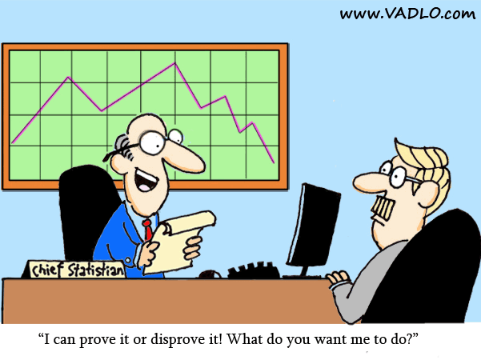

**R and RStudio Review**

There is no possible way to make you into an R wizard during our time together. Given the assumptions of this course, it’s also not likely to be a good use of time.

So we’re really just going to cover the basics. If you are interested, Google is your friend, and I would also recommend [R for Data Science](https://r4ds.had.co.nz) by Hadley Wickham—this guy is a LEGEND in the R community.

Lets do some live coding!

Head over to RStudio Cloud: https://rstudio.cloud/

If you don’t have a lot of experience programming, this can seem a little overwhelming.

Trust me—you’ll get comfortable with the approach soon, and it’s better than the alternate pedagogy!

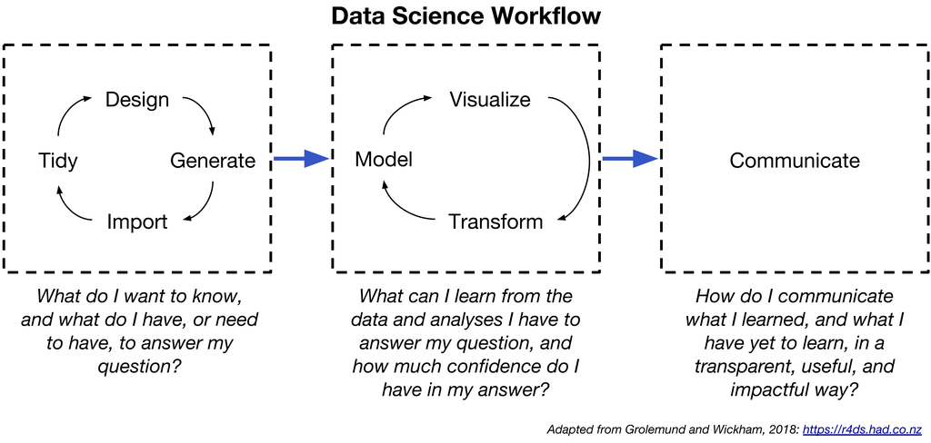

The critical skill isn’t the ability to write code. The critical skills are the ability to:

- Ask insightful—and valuable—questions
- Collect data that helps answer those questions
- Analyze that data to derive a meaningful answer
- Communicate that answer to influence and shape decision making

We are going to talk a lot about the assumptions made by the analyses you run, the measures you are using, and the way the data was collected.

My goal isn’t to make you rock-star programmers and stats-nerds, it’s to build your ability to **think statistically** and to understand the strengths *and* [limitations](http://www.drbanderson.com/2017/06/20/the-grand-theory-of-entrepreneurship-fallacy/) of data science.

Lets go a little deeper with generating research questions.

With statistics, we’re trying to make sense of what has happened (descriptive) in order to make a reasonably accurate guess of what will happen (prescriptive).

Statistical analysis is ALWAYS retrospective. We can’t analyze anything until AFTER it’s happened.

So if our goal is to make a good guess at what will happen—to understand that **IF** $x$ occurs or changes **THEN** $y$ occurs or changes—we need to have a good handle on *causal inference*.

**Necessary and sufficient conditions for causality**

$$x —> y$$

- Temporal sequencing ($x$ happens before $y$)
- The relationship must not be spurious (the effect of $x$ on $y$ could not have occurred by random chance)
- There must be no other possible explanations (there isn’t another factor, $z$, influencing the $x$ —> $y$ relationship)

Outside of experimental physics (and even then, there is error), it’s really, really, **really** hard to establish true, unequivocal, causal relationships.

So, the method we use to go about our research and analyses matters to maximizing what causal understanding that may infer from the questions—the *hypotheses*—that we ask.

$$x —> y$$

A hypothesis is a statement of a relationship.

You can’t be in a relationship with yourself, so a hypothesis must have at least two characters.

Most hypotheses deal with change and/or with appearance. A hypothesis does not *have* to be causal, but usually it is, because we are most interested in causal effects.

- A change in $x$ is associated with a change in $y$.
- The appearance of $x$ is associated with the appearance of $y$.
- A change in $x$ causes a change in $y$.
- The appearance of $x$ causes a change in $y$.
- The appearance of $x$ causes the appearance of $y$.

I really dislike this phrase, but I’d be remiss if I didn’t include it…

**Correlation does not imply causation.**

Determining a causal relationship is a function of research design and the *data ganeration process*.

Rarely do we actually get the conditions to test for a true causal relationship, so despite what we say with our hypothesis, the vast majority of time we are evaluating statements of association (correlation).

Correlation has a lot of value, but it’s limited.

A brief note about null hypotheses, p-values, frequentist statistics, and Bayesian inference.

Lets load some data!

```r
library(tidyverse)

school.df <- read_csv("SchoolData.csv")
```

```r
head(school.df, 10)
```

```
## # A tibble: 10 x 15
##    SchoolID Name  PercentStudents… PercentBachelor… PercentGraduate…
##       <dbl> <chr>            <dbl>            <dbl>            <dbl>
##  1   100654 Alab…             8.00            13                6.86
##  2   100663 Univ…            26.0             15.9              8.55
##  3   100690 Amri…            83.0             13.2              7.01
##  4   100706 Univ…            29.0             17.7              8.91
##  5   100724 Alab…            11.0             11.8              6.76
##  6   100751 The …            10.0             16.5              9.21
##  7   100760 Cent…            42.0              7.97             4.55
##  8   100812 Athe…            61.0             11.9              6.17
##  9   100830 Aubu…            32.0             14.7              9.09
## 10   100858 Aubu…             7.00            17.9             10.8
## # ... with 10 more variables: PercentBornUS_Census <dbl>,
## #   MedianHouseHoldInc_Census <dbl>, PovertyRate_Census <dbl>,
## #   UnemploymentRate_Census <dbl>, MeanEarningsOverall <dbl>,
## #   CountFemaleWorking <dbl>, CountMaleWorking <dbl>,
## #   PercentEarningOver25K <dbl>, MeanEarningsFemale <dbl>,
## #   MeanEarningsMale <dbl>
```

```r
names(school.df)
```

```
##  [1] "SchoolID"                  "Name"
##  [3] "PercentStudentsOver23"     "PercentBachelors_Census"
##  [5] "PercentGraduate_Census"    "PercentBornUS_Census"
##  [7] "MedianHouseHoldInc_Census" "PovertyRate_Census"
##  [9] "UnemploymentRate_Census"   "MeanEarningsOverall"
## [11] "CountFemaleWorking"        "CountMaleWorking"
## [13] "PercentEarningOver25K"     "MeanEarningsFemale"
## [15] "MeanEarningsMale"
```

So what are we looking at?

This is a subset of data from the US Department of Education’s [College Scorecard](https://collegescorecard.ed.gov/data/) project. Many of the variables you see are metrics collected from a sample of students ten years after *entering* the school.

Ok, your boss just sends you a collection of MS Excel spreadsheets and says, effectively, “see what you can make of this.”

Where do you start?

The first step is to [tidy the data](http://vita.had.co.nz/papers/tidy-data.pdf), but that’s for a later session. Personally, I like to start with a visualization, to get a sense of what’s going on with the data, and to see if there are interesting patterns worth exploring.

`Base R` versus the [`tidyverse`](https://www.tidyverse.org)—we use the `tidyverse` in this class.

Lets start with the basics…

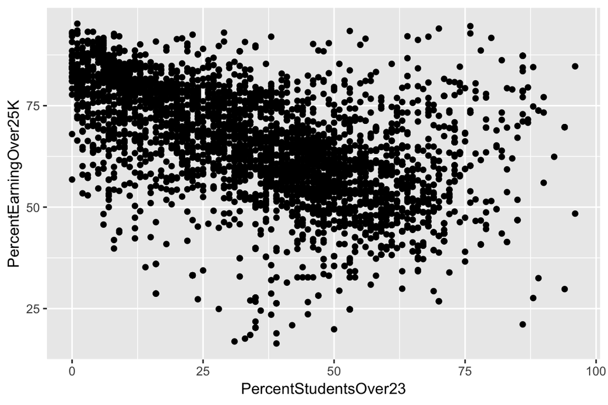

```r
ggplot(data = school.df, aes(y = PercentEarningOver25K,
                             x = PercentStudentsOver23)) +
  geom_point()
```

Lets add an estimate of the linear trend…

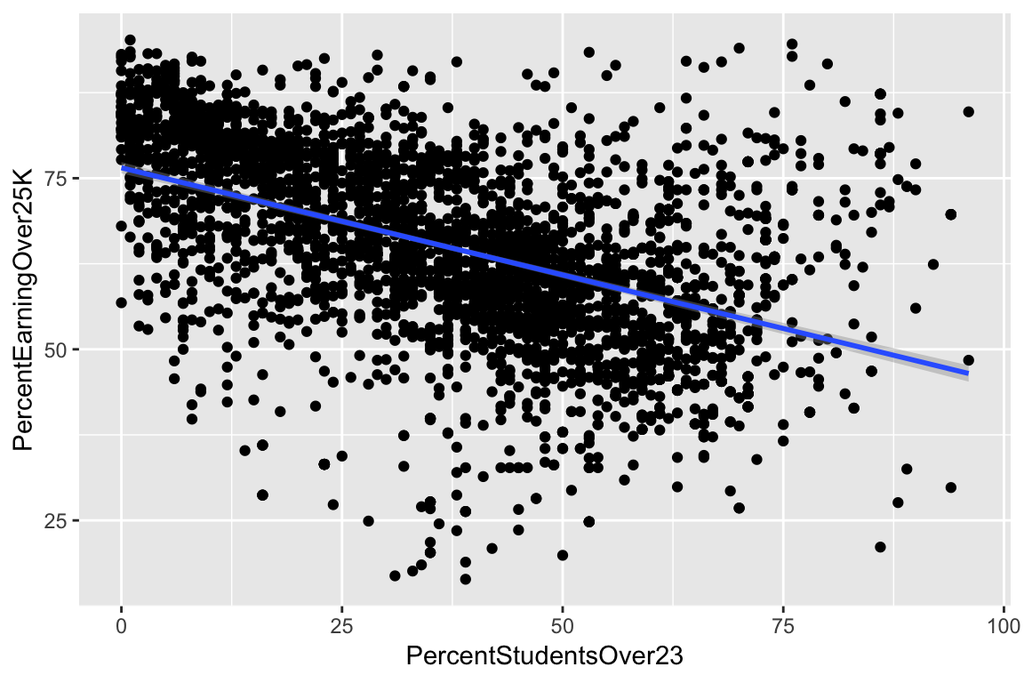

```r
ggplot(data = school.df, aes(y = PercentEarningOver25K,
                             x = PercentStudentsOver23)) +
  geom_point() +
  geom_smooth(method = "lm")
```

Lets keep the linear trend, and let the data speak to us a bit…

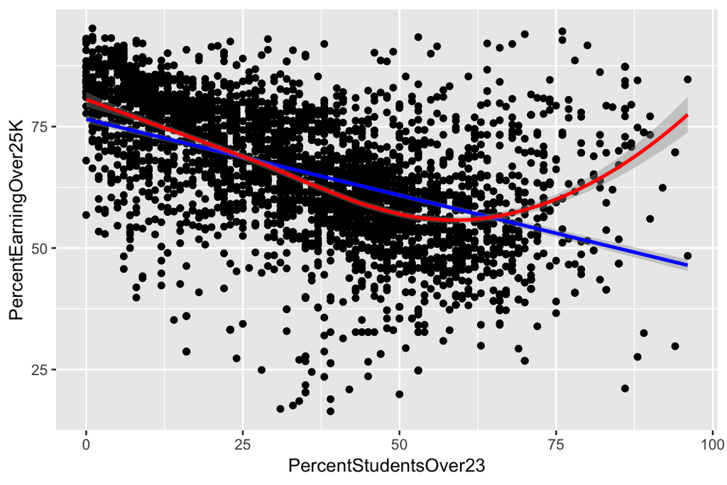

```r
ggplot(data = school.df, aes(y = PercentEarningOver25K,
                             x = PercentStudentsOver23)) +
  geom_point() +
  geom_smooth(method = "lm", color = "blue") +
  geom_smooth(method = "loess", color = "red")
```

This isn’t a very attractive plot—lets add some labels and a legend:

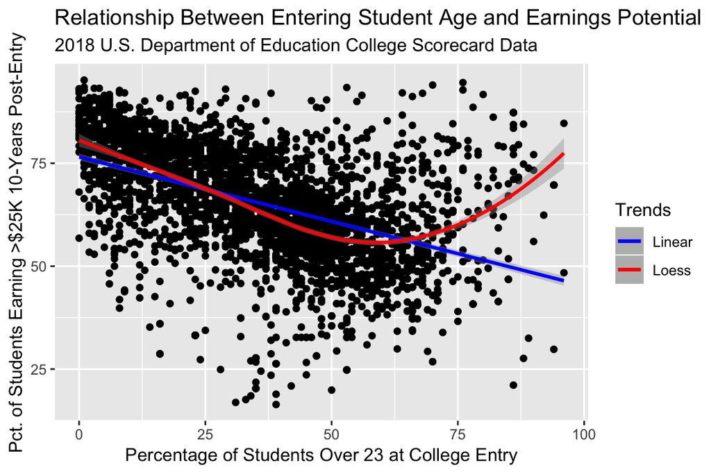

```r
ggplot(data = school.df, aes(y = PercentEarningOver25K,
                             x = PercentStudentsOver23)) +
  geom_point() +
  geom_smooth(method = "lm", aes(color = "Linear")) +
  geom_smooth(method = "loess", aes(color = "Loess")) +
  labs(title = "Relationship Between Entering Student Age and Earnings Potential",
       subtitle = "2018 U.S. Department of Education College Scorecard Data",
       x = "Percentage of Students Over 23 at College Entry",
       y = "Pct. of Students Earning >$25K 10-Years Post-Entry") +
  scale_color_manual(name = "Trends", values = c("blue", "red"))
```

Lets estimate a simple linear model…

```r
linear.model <- lm(PercentEarningOver25K ~ PercentStudentsOver23,
                   data = school.df)
summary(linear.model)
```

```
##
## Call:
## lm(formula = PercentEarningOver25K ~ PercentStudentsOver23, data = school.df)
##
## Residuals:
##     Min      1Q  Median      3Q     Max
## -49.918  -7.001   0.495   7.947  41.871
##
## Coefficients:
##                        Estimate Std. Error t value Pr(>|t|)
## (Intercept)           76.523071   0.420083  182.16   <2e-16 ***
## PercentStudentsOver23 -0.313074   0.009717  -32.22   <2e-16 ***
## ---
## Signif. codes:  0 '***' 0.001 '**' 0.01 '*' 0.05 '.' 0.1 ' ' 1
##
## Residual standard error: 12.09 on 3315 degrees of freedom
## Multiple R-squared:  0.2385, Adjusted R-squared:  0.2382
## F-statistic:  1038 on 1 and 3315 DF,  p-value: < 2.2e-16
```

Now a polynomial model…

```r
curve.model <- lm(PercentEarningOver25K ~ PercentStudentsOver23 +
                    I(PercentStudentsOver23^2), data = school.df)
summary(curve.model)
```

```
##
## Call:
## lm(formula = PercentEarningOver25K ~ PercentStudentsOver23 +
##     I(PercentStudentsOver23^2), data = school.df)
##
## Residuals:
##     Min      1Q  Median      3Q     Max
## -46.999  -6.144   1.072   7.137  35.874
##
## Coefficients:
##                              Estimate Std. Error t value Pr(>|t|)
## (Intercept)                84.1730924  0.5834376  144.27   <2e-16 ***
## PercentStudentsOver23      -0.8780609  0.0326499  -26.89   <2e-16 ***
## I(PercentStudentsOver23^2)  0.0072281  0.0004005   18.05   <2e-16 ***
## ---
## Signif. codes:  0 '***' 0.001 '**' 0.01 '*' 0.05 '.' 0.1 ' ' 1
##
## Residual standard error: 11.53 on 3314 degrees of freedom
## Multiple R-squared:  0.3066, Adjusted R-squared:  0.3062
## F-statistic: 732.7 on 2 and 3314 DF,  p-value: < 2.2e-16
```

Now the big question…which model is the “best”?

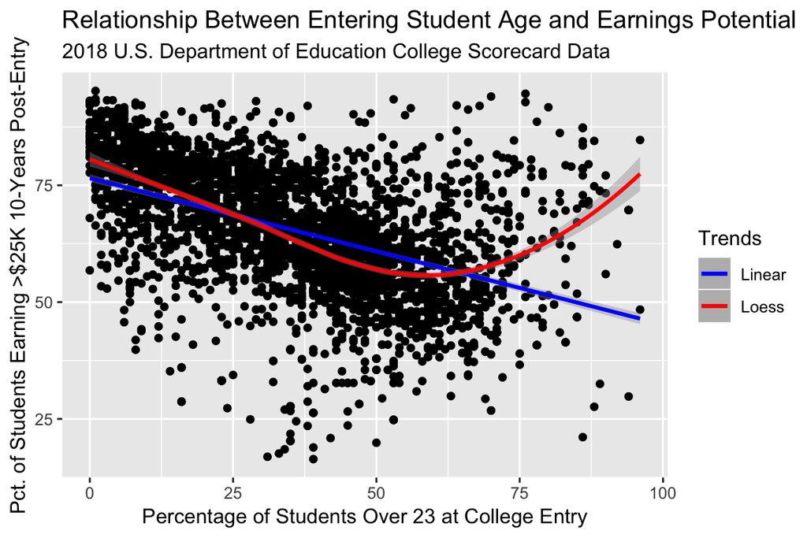

A commonly used threshold for a p-value to infer a statistically significant difference is p <= .05, or equivalently, 1 in 20.

The p-value is the probability of observing an effect (or equivalently, a difference) as large as you observed or larger by chance alone, **assuming the null hypothesis is true**.

1:20

So here’s the big question. Do you take those odds if you are…

- Betting on a ball game?
- Betting on a new product introduction being successful?
- Betting on your life?

**Data and statistical analyses are just tools. Like any other tool, they can be misused. You need to know what your tools can—and more importantly can not—do to use them effectively.**

So what’s the single most important trait for a data scientist?

Easy…*Humility*

Team deliverable—Going deeper with the school data.

**Session Wrap-up and Questions**

Next Session: Saturday, 26 January, 8:00AM—Measures, Proxies, Constructs & Measurement Error